# A Super Brief Tutorial of R, Rstudio, R markdown, and Python

Me

# Writing and equations

Textual input is just like any other word processor. If you wish to have specific formats, you can check out the R markdown cheat sheet that is available in the `Help -> Cheat Sheets` menu of R Studio.

Within an R markdown file, you can choose the type of output: HTML, PDF or Word. If you choose the `output: html_notebook`, you will get the option of previewing the document (which I find quite useful).

#Not recognized even though RStudio colors the text like a header…

The same goes for options in the YAML header at the top of the document, lists, tables, etc. These environments all rely on proper indentation to get the desired effects.

For writing equations, I recommend using standard LaTeX commands such as `$\alpha^2 + \beta = \frac{1}{2}$` gives $\alpha^2 + \beta = \frac{1}{2}$. If you wish to have the equation be on its own line (instead of in-line) use `$$\alpha^2 + \beta = \frac{1}{2}$$` which gives
$$\alpha^2 + \beta = \frac{1}{2}.$$

Lastly, you can do in-line R evaluation if you want. You do this by typing something like $e^5 =$ 148.4131591. This comes in handy if you want to pull values from stored objects into your writing.

Again, if you need help with something in R markdown, I highly recommend looking at the cheat sheet; it will help you do most tasks.

# Basic R input

The following shows just some basic evaluation of some R code in an R markdown file. The evaluation environment begins and ends with 3 backward ticks “`”. After the first 3 backward ticks, you have something like `{r BLOCK NAME, option1 = ..., option 2 = ..., ...}` Options can specify, e.g., whether you want the code to show up (`include = FALSE or TRUE`) and many other formatting preferences.

Here is a super basic example of doing some R evaluation:

```r
1 + 1
```

```
[1] 2
```

```r
sin(2*pi)
```

```
[1] -2.449294e-16
```

```r
runif(10)
```

```
 [1] 0.8187046 0.7565856 0.1258672 0.5489158 0.4085410 0.2696786 0.7835720 0.9718321 0.9752570
[10] 0.9773028
```

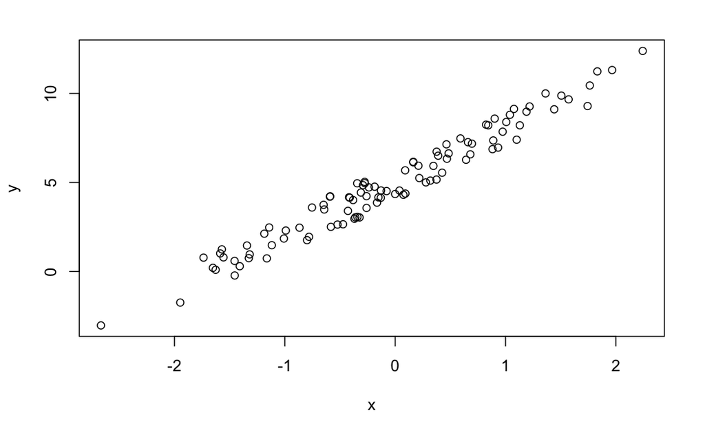

```r
x <- rnorm(100)
y <- 3*x + 5 + runif(100, -1, 1)
plot(x,y)
```

# Python in R markdown

Using Python in R requires the installation of the `reticulate` library.

```python
reticulate::repl_python()
```

```
Python 3.6.13 (/Users/bridenho/Library/r-miniconda/envs/r-reticulate/bin/python)
Reticulate 1.20 REPL -- A Python interpreter in R.
```

```python
import matplotlib.pyplot as plt
import numpy as np
```

## Including Plots (sub-header example)

Here I continue using the Python interpreter to create a plot:

```python
reticulate::repl_python()
```

```
Python 3.6.13 (/Users/bridenho/Library/r-miniconda/envs/r-reticulate/bin/python)
Reticulate 1.20 REPL -- A Python interpreter in R.
```

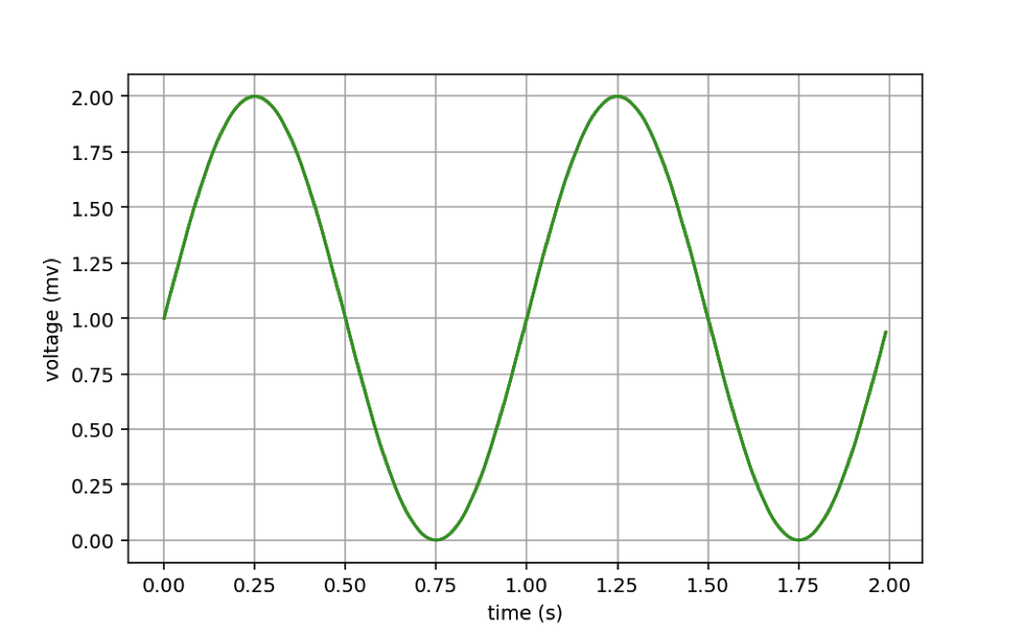

```python
t = np.arange(0.0, 2.0, 0.01)
s = 1 + np.sin(2*np.pi*t)

plt.plot(t, s)
plt.xlabel('time (s)')
plt.ylabel('voltage (mv)')
plt.grid(True)
#plt.savefig("test.png")
plt.show()
```